# affinitymatrix

## Example

The example below shows how to use the main function of the package, `estimate.affinity.matrix`, and how to summarize its findings. We first generate a random sample of *matches*: the values of the normalized variance-covariance matrix used in the data generating process are taken from Chiappori, Ciscato and Guerriero (2020). For the sake of clarity, consider the marriage market example: every row of our data frame corresponds to a couple. The first `Kx` columns correspond to the husbands’ characteristics, or *matching variables*, while the last `Ky` columns correspond to the wives’. The key inputs to feed to `estimate.affinity.matrix` are two matrices `X` and `Y` corresponding to the husbands’ and wives’ traits and sorted so that the i-th man in `X` is married to the i-th woman in `Y`.

```r
# Load
library(affinitymatrix)

# Parameters
Kx = 4; Ky = 4; # number of matching variables on both sides of the market
N = 100 # sample size
mu = rep(0, Kx+Ky) # means of the data generating process
Sigma = matrix(c(1, 0.326, 0.1446, -0.0668, 0.5712, 0.4277, 0.1847, -0.2883, 0.326, 1, -0.0372, 0.0215, 0.2795, 0.8471, 0.1211, -0.0902, 0.1446, -0.0372, 1, -0.0244, 0.2186, 0.0636, 0.1489, -0.1301, -0.0668, 0.0215, -0.0244, 1, 0.0192, 0.0452, -0.0553, 0.2717, 0.5712, 0.2795, 0.2186, 0.0192, 1, 0.3309, 0.1324, -0.1896, 0.4277, 0.8471, 0.0636, 0.0452, 0.3309, 1, 0.0915, -0.1299, 0.1847, 0.1211, 0.1489, -0.0553, 0.1324, 0.0915, 1, -0.1959, -0.2883, -0.0902, -0.1301, 0.2717, -0.1896, -0.1299, -0.1959, 1),
               nrow=Kx+Ky) # (normalized) variance-covariance matrix of the data generating process
labels_x = c("Educ.", "Age", "Height", "BMI") # labels for men's matching variables
labels_y = c("Educ.", "Age", "Height", "BMI") # labels for women's matching variables

# Sample
data = MASS::mvrnorm(N, mu, Sigma) # generating sample
X = data[,1:Kx]; Y = data[,Kx+1:Ky] # men's and women's sample data
w = sort(runif(N-1)); w = c(w,1) - c(0,w) # sample weights

# Main estimation
res = estimate.affinity.matrix(X, Y, w = w, nB = 500)
```

```
#> Setup...
#> Main estimation...
#> Saliency analysis...
#> Rank tests...
#> Saliency analysis (bootstrap)...
```

The output of `estimate.affinity.matrix` is a list of objects that constitute the estimation results. The estimated affinity matrix is stored under `Aopt`, while the vector of loadings describing men’s and women’s matching factors are stored under `U` and `V` respectively. The following functions can be used to produce summaries of the different findings. For further details, Chiappori, Ciscato and Guerriero (2020) contain tables and plots that are generated with these functions.

```r
# Print affinity matrix with standard errors
table1 = show.affinity.matrix(res, labels_x = labels_x, labels_y = labels_y)
# Here we print a Markdown version: we recommend using the function export.table to store the tables in a txt file
# export.table(table1, name = "affinity_matrix", "path = "myresults")
gsub("\\}", "***", gsub("\\\\|hline|textbf\\{|\t|&|\n", "", table1))
```

```
#>       [,1]     [,2]      [,3]      [,4]      [,5]
#>  [1,] ""       "Educ."   "Age"     "Height"  "BMI"
#>  [2,] "Educ."  "1.12***" "0.39"    "0.08"    "-0.45***"
#>  [3,] ""       "(0.25) " "(0.34) " "(0.18) " "(0.18) "
#>  [4,] "Age"    "-0.52"   "4.48***" "0.98***" "0.69***"
#>  [5,] ""       "(0.35) " "(0.71) " "(0.29) " "(0.28) "
#>  [6,] "Height" "0.15"    "0.41"    "0.10"    "-0.12"
#>  [7,] ""       "(0.17) " "(0.26) " "(0.13) " "(0.13) "
#>  [8,] "BMI"    "0.78***" "0.14"    "0.10"    "0.07"
#>  [9,] ""       "(0.19) " "(0.27) " "(0.14) " "(0.14) "
```

```r
# Print diagonal elements of the affinity matrix with standard errors
table2 = show.diagonal(res, labels = labels_x)
# export.table(table2, name = "diagonal_affinity_matrix", "path = "myresults")
gsub("\\}", "***", gsub("\\\\|hline|textbf\\{|\t|&|\n", "", table2))
```

```
#>      [,1]      [,2]      [,3]     [,4]
#> [1,] "Educ."   "Age"     "Height" "BMI"
#> [2,] "1.12***" "4.48***" "0.10"   "0.07"
#> [3,] "(0.25)"  "(0.71)"  "(0.13)" "(0.14)"
```

```r
# Print rank test summary
table3 = show.test(res)
# export.table(table3, name = "rank_tests", "path = "myresults")
gsub("\\}", "***", gsub("\\\\|hline|textbf\\{|\t|&|\n", "", table3))
```

```
#>      [,1]               [,2]    [,3]    [,4]
#> [1,] "$H_0$: $rk(A)=k$" "$k=1$" "$k=2$" "$k=3$"
#> [2,] "$chi^2$"          "36.55" "6.62"  "0.06"
#> [3,] "$df$"             "9"     "4"     "1"
#> [4,] "Rejected?"        "Yes"   "No"    "No"
```

```r
# Print results from saliency analysis
table4 = show.saliency(res, labels_x = labels_x, labels_y = labels_y, ncol_x = 2, ncol_y = 2)
# export.table(table4$U.table, name = "saliency_men", "path = "myresults")
# export.table(table4$V.table, name = "saliency_women", "path = "myresults")
gsub("\\}", "***", gsub("\\\\|hline|textbf\\{|\t|&|\n|$", "", table4$U.table))
```

```
#>      [,1]           [,2]      [,3]
#> [1,] ""             "Index 1" "Index 2"
#> [2,] "Educ."        "0.05"    "0.85***"
#> [3,] "Age"          "1.00***" "-0.06***"
#> [4,] "Height"       "0.08"    "0.16"
#> [5,] "BMI"          "0.02"    "0.51***"
#> [6,] " Index share" "0.72"    "0.22"
```

```r
gsub("\\}", "***", gsub("\\\\|hline|textbf\\{|\t|&|\n|$", "", table4$V.table))
```

```
#>      [,1]           [,2]       [,3]
#> [1,] ""             "Index 1"  "Index 2"
#> [2,] "Educ."        "-0.09***" "0.95***"
#> [3,] "Age"          "0.96***"  "0.12***"
#> [4,] "Height"       "0.21***"  "0.05"
#> [5,] "BMI"          "0.14***"  "-0.28***"
#> [6,] " Index share" "0.72"     "0.22"
```

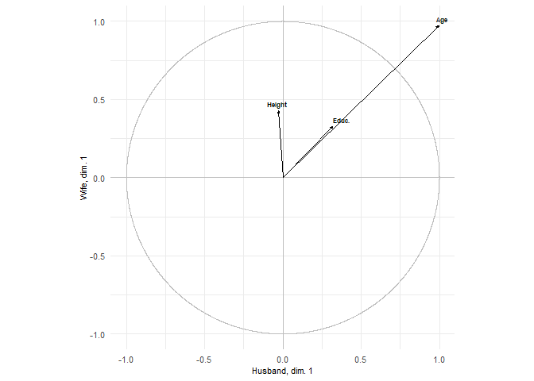

```r
# Show correlation between observed variables and matching factors
plots = show.correlations(res, labels_x = labels_x, labels_y = labels_y,
                          label_x_axis = "Husband", label_y_axis = "Wife")
# for (d in 1:length(plots)) ggsave(paste0("myresults/plot_",d) plot = plots[d])
plots[1]
```

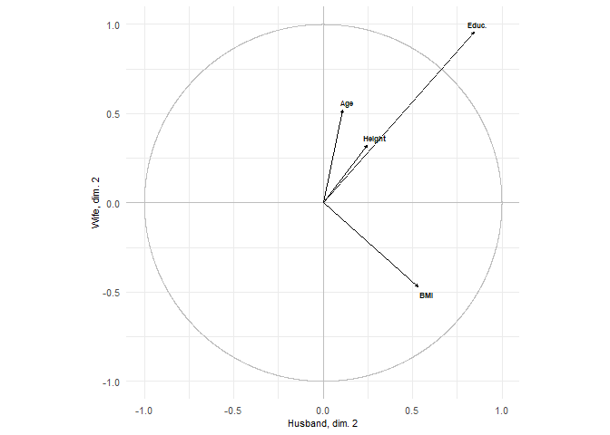

```r
plots[2]
```

## Literature

Ciscato, Edoardo, Alfred Galichon, and Marion Gousse. ‘Like attract like? a structural comparison of homogamy across same-sex and different-sex households.’ *Journal of Political Economy* 128, no. 2 (2020): 740-781.

Chiappori, Pierre-André, Edoardo Ciscato, and Carla Guerriero. ‘Analyzing matching patterns in marriage: theory and application to Italian data.’ *HCEO Working Paper* no. 2020-080 (2020).

Dupuy, Arnaud, and Alfred Galichon. ‘Personality traits and the marriage market.’ *Journal of Political Economy* 122, no. 6 (2014): 1271-1319.

Dupuy, Arnaud, Alfred Galichon, and Yifei Sun. ‘Estimating matching affinity matrices under low-rank constraints.’ *Information and Inference: A Journal of the IMA* 8, no. 4 (2019): 677-689.